# assignment

Felix Gerbaldo

3 5 2023

```r
suppressPackageStartupMessages({
  library(epiwraps)
  library(motifmatchr)
  library(MotifDb)
  library(universalmotif)
  library(sechm)
  library(BiocParallel)
  library(ggplot2)
  library(chromVAR) # for motif accessibility estimation
  library(SummarizedExperiment) # data structure
  library(limma) # for statistical analysis
  library(BSgenome.Mmusculus.UCSC.mm10)
})
```

```
## See system.file("LICENSE", package="MotifDb") for use restrictions.
```

```r
# to control multithreading, unix users can use:
register(MulticoreParam(4))
```

perform a chromVAR motif analysis, and run 2 differential motif accessibility analyses, respectively: 1. comparing stressed (denoted ‘FSS’ – forced swim stress) and control animals 2. comparing male and female animals

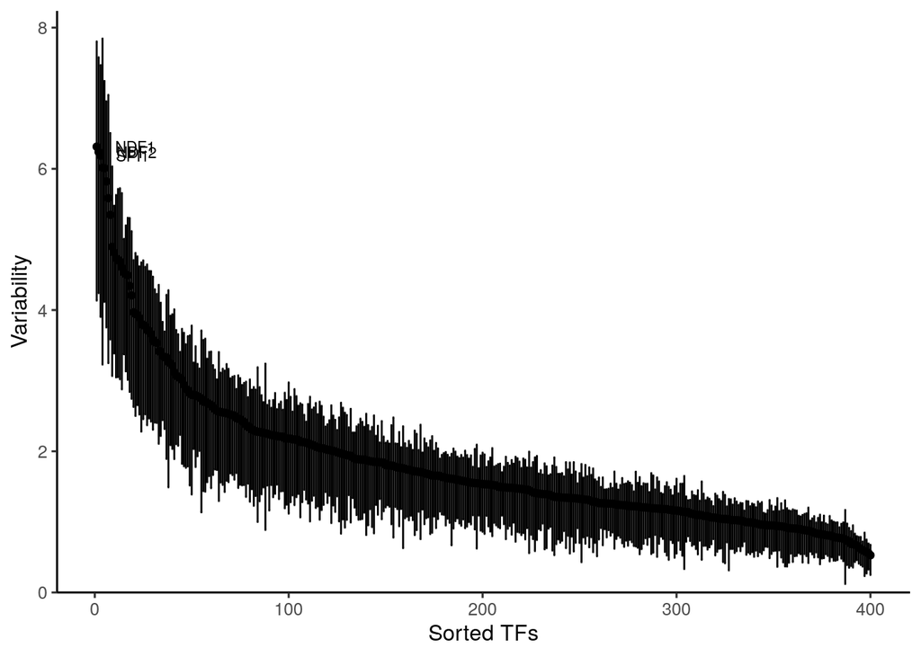

```r
data <- readRDS("mouse_mm38_hippocampus.peakCounts.SE.rds")

motifs <- query(MotifDb, c("HOCOMOCOv11-core", "Hsapiens"))
motifs <- do.call(TFBSTools::PWMatrixList, setNames(
           universalmotif::convert_motifs(motifs, class="TFBSTools-PWMatrix"),
           mcols(motifs)$geneSymbol))

genome <- Rsamtools::FaFile("/mnt/reference/reference/Mus_musculus/Ensembl/GRCm38/Sequence/WholeGenomeFasta/Mus_musculus.GRCm38.dna_sm.primary_assembly.fa")

data <- chromVAR::addGCBias(data, genome=genome)

moi <- motifmatchr::matchMotifs(motifs, subject=data, genome=genome)

dev <- chromVAR::computeDeviations(object = data, annotations=moi,    background_peaks=getBackgroundPeaks(data, niterations=1000))

variability <- computeVariability(dev)
plotVariability(variability)
```

```r
assays(dev)$norm <- scale(assays(dev)$z)
dev$condition <- c("CTRL",
                   "CTRL",
                   "CTRL",
                   "CTRL",
                   "CTRL",
                   "CTRL",
                   "FSS",
                   "FSS",
                   "FSS",
                   "FSS",
                   "FSS",
                   "FSS")

dev$sex <- c("F",
             "F",
             "F",
             "M",
             "M",
             "M",
             "F",
             "F",
             "F",
             "M",
             "M",
             "M")
colData(dev)
```

```
## DataFrame with 12 rows and 3 columns
##                                   depth   condition         sex
##                               <numeric> <character> <character>
## Control_female_GSM6041841.bam  73170149        CTRL           F
## Control_female_GSM6041842.bam  93995034        CTRL           F
## Control_female_GSM6041843.bam  40167775        CTRL           F
## Control_male_GSM6041844.bam    70491005        CTRL           M
## Control_male_GSM6041845.bam    84985977        CTRL           M
## ...                                 ...         ...         ...
## FSS_female_GSM6041854.bam      73674456         FSS           F
## FSS_female_GSM6041855.bam      49285912         FSS           F
## FSS_male_GSM6041856.bam        82385764         FSS           M
## FSS_male_GSM6041857.bam        68623011         FSS           M
## FSS_male_GSM6041858.bam        81801232         FSS           M
```

For each analysis, report the top most significant motifs, plot a heatmap of the normalized accessibility scores across the samples for those motifs, and write a short paragraph interpreting the results.

```r
mm <- model.matrix(~dev$condition)

fit <- eBayes(lmFit(assays(dev)$norm, mm))

res <- as.data.frame(topTable(fit, number = Inf))
```

```
## Removing intercept from test coefficients
```

```r
head(res)
```

```
##            logFC     AveExpr         t      P.Value  adj.P.Val         B
## GCR    4.3759862  0.24142451  5.548601 6.761815e-05 0.01815628  1.916374
## PRGR   3.5534564  0.26517511  5.386078 9.078142e-05 0.01815628  1.648814
## MEF2C -1.1936720 -0.13705883 -2.477448 2.636341e-02 0.99605094 -3.561107
## CDX1   0.8604701  0.04148516  2.196703 4.508932e-02 0.99605094 -4.037141
## MEF2A -0.9678479 -0.06503108 -2.161811 4.814202e-02 0.99605094 -4.094546
## MEF2D -1.1399491 -0.08077352 -2.107154 5.331229e-02 0.99605094 -4.183579
```

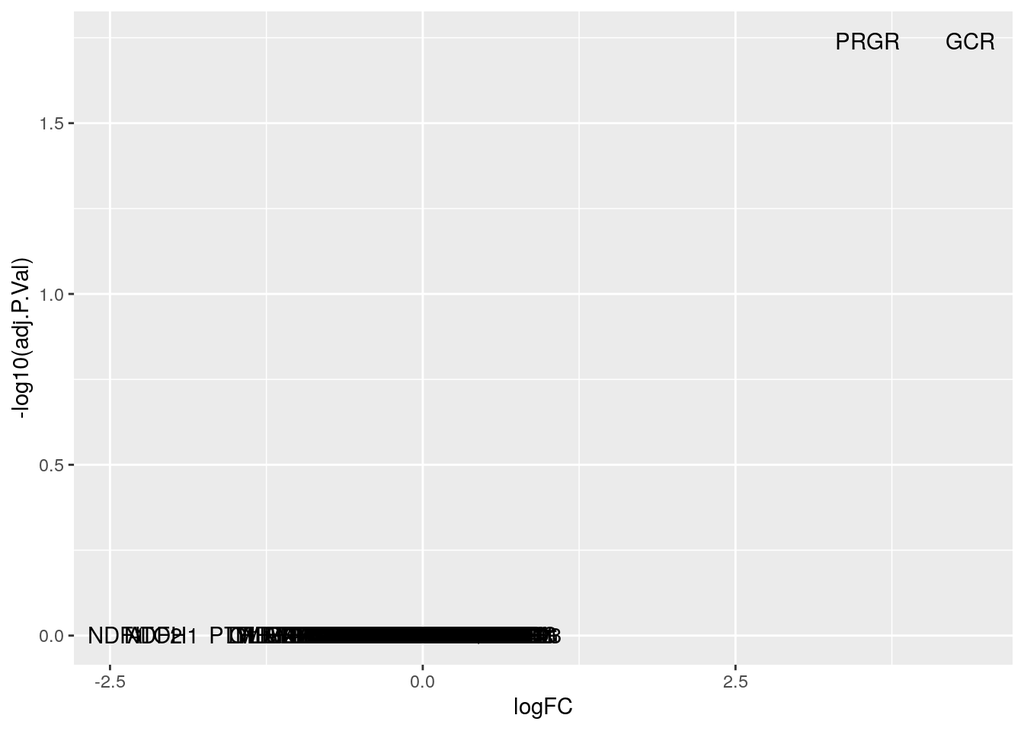

```r
res$TF <- row.names(res)
ggplot(res, aes(logFC, -log10(adj.P.Val), label=TF)) + geom_text()
```

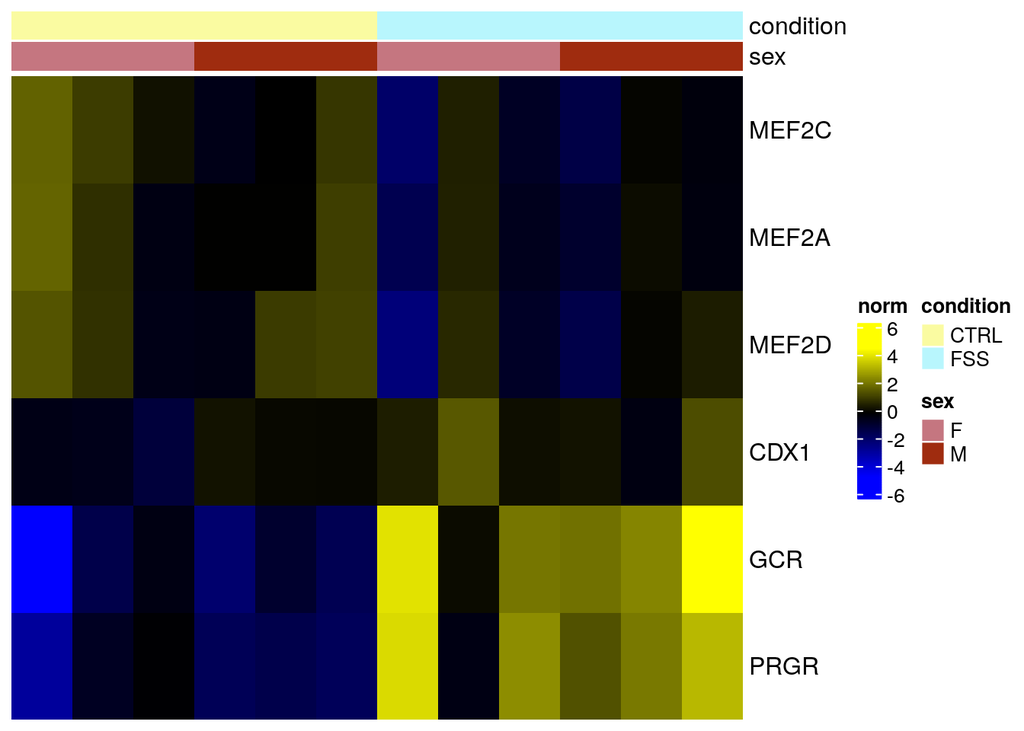

```r
sechm(dev, features = head(row.names(res)), assayName="norm", top_annotation = c("condition", "sex"))
```

Comparing the two experimental conditions with each other, only two TFs are identified as significantly differentially accessible. The upregulation of the GCR makes sense given its involvement in both short and long-term adaptations in response to stressors (according to Wikipedia..). PRGR likely only came up due to the high similarity between the two TFs binding motifs.

```r
mm <- model.matrix(~dev$sex)

fit <- eBayes(lmFit(assays(dev)$norm, mm))

res <- as.data.frame(topTable(fit, number = Inf))
```

```
## Removing intercept from test coefficients
```

```r
head(res)
```

```
##           logFC     AveExpr          t      P.Value    adj.P.Val         B
## ZFP42 -4.458329 -0.39205913 -10.864865 2.447072e-08 9.788288e-06 9.5361451
## TYY1  -4.540425 -0.21299847  -9.235394 1.933857e-07 3.867714e-05 7.5709786
## ZN384 -2.955291 -0.07135420  -7.073612 4.696154e-06 6.261539e-04 4.4560057
## Z324A -2.162371 -0.05998602  -6.833969 6.934904e-06 6.934904e-04 4.0705842
## THAP1 -2.170926  0.02453267  -6.561871 1.089828e-05 8.718623e-04 3.6227663
## WT1   -1.907693 -0.13160797  -5.075273 1.540946e-04 9.023340e-03 0.9876097
```

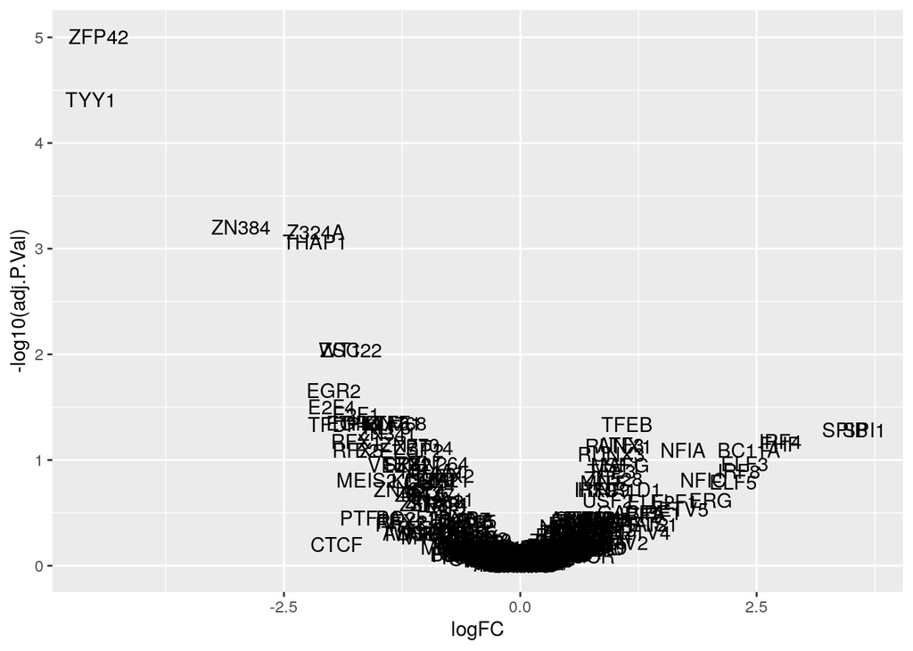

```r
res$TF <- row.names(res)
ggplot(res, aes(logFC, -log10(adj.P.Val), label=TF)) + geom_text()
```

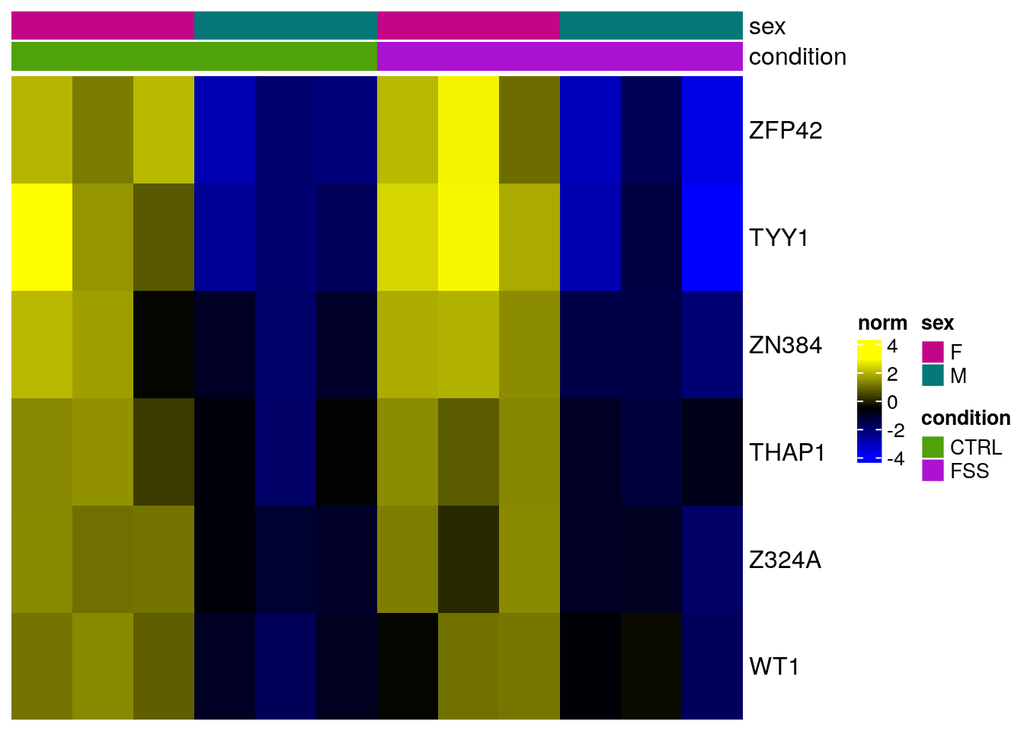

```r
sechm(dev, features = head(row.names(res)), assayName="norm", top_annotation = c("sex", "condition"))
```

Comparing males and females, several zinc finger proteins (ZFP42, TYY1, Z324A, ZN384) come up as significantly differentially active as well as the TF THAP1. The two most significant findings (ZFP42 and TYY1) are both involved in cell differentiation, suggesting that the cells obtained might have differed in their overall developmental state between male and female mice at the time the experiment was conducted.